# CHAPTER A4

航空機における一般荷重

## A4.1 イントロダクション

航空機の構造設計を行う前に、飛行、着陸、および離陸状態において航空機に作用する外力を知る必要がある。現代の航空機は亜音速、遷音速、超音速の速度領域で飛行するため、航空機に作用する空気荷重を完全に決定するには、空気力学に関する徹底的な理論的知識が必要である。さらに、直線テーパー翼、後退翼、デルタ翼など、多種多様な主翼形状が存在し、これらの主翼の多くには、より優れた揚力や制御特性を促進するための前縁および後縁デバイスが含まれている。パワーユニットのナセル、外部燃料タンクなどの存在は、主翼周囲の流れに影響を与え、その結果、主翼上の空気力の大きさと分布に影響を与える。同様に、胴体や航空機本体自体も主翼上の流れに影響を及ぼす。航空機に作用する空気荷重の理論的計算は、構造の教科書で扱うには広すぎるテーマであり、大学の航空カリキュラムではこのテーマに対して個別のコースを設けるのが一般的である。

ほとんどの航空機会社において、航空機に作用する荷重は構造解析部門に配属された技術者のグループによって決定され、このグループは「航空機荷重計算グループ」と呼ばれることが多い。このグループの業務は主に空気力学の応用に依存しているが、航空機構造がこれらの空気力を安全かつ効率的に支持できるように適切に設計できるように、航空機に作用する空気荷重の大きさと分布を決定することに関わる空気力学の局面に焦点を当てている。航空機会社の技術部門には、独立したまたは個別の空気力学セクションが存在するが、一般的に彼らの任務は、航空機の性能、安定性、および操縦性を保証または担保するために空気力学という主題を利用することである。

航空機の構造理論を学習する上で、航空機に作用する荷重に関する基本的な全般的知識を持つことが望ましいため、本章ではこの情報を提供することを試みる。主翼の設計を扱う後の章において、この主題はさらに詳しく展開される。

## A4.2 制限荷重または実用荷重。設計荷重。

航空機は特定の任務を遂行するために設計されているため、サイズ、形状、性能に応じて多くのタイプの航空機が存在することになる。例えば、ダグラス DC-8 のような民間輸送機は、一定数の乗客を安全、効率的、かつ快適に空港間で様々な距離を輸送する任務を果たすように設計されている。一方、空軍の戦闘機タイプの航空機は、敵機を撃墜したり、低速の味方機を護衛したりする任務を担っている。この任務を効率的に遂行するには、DC-8 輸送機と比較して極めて異なる形状が必要となる。さらに、戦闘機タイプの航空機は、求められる任務を遂行するために、DC-8 よりもはるかに急激な操縦（マニューバ）を行わなければならない。

一般に、航空機に作用する空気力の大きさは、航空機の速度と、その速度の大きさおよび方向が変化する割合（加速度）に依存する。飛行加速度因子の大きさは、戦闘機のような場合には、人体がこれらの加速度慣性力に負傷することなく耐えうる限界によって制限されることがある。他方、DC-8 の操縦加速度は、人体が耐えうる限界によって決定されるのではなく、乗客をある空港から別の空港へ安全に輸送するために何が必要かによって決定される。

航空機の構造を、求められる任務の遂行中に受ける荷重よりも大きな荷重に対して設計することは、明らかに航空機にかなりの重量を追加することになり、設計された任務に対する性能や総合的な効率を低下させることになる。

特に航空輸送の安全性を確保し、設計の統一性と効率性を図るために、政府の航空機関（民間および軍事）は、航空機の構造設計に使用される荷重の大きさに関して、様々なタイプの航空機に対して明確な規定を設けている。これらの規定された航空機荷重を一般的に指す場合、以下の2つの用語が使用される。

### 制限荷重（Limit Loads）または実用荷重（Applied Loads）

制限荷重（Limit Loads）と実用荷重（Applied Loads）という用語は同じ荷重を指し、民間機関（C.A.A.）は制限荷重という用語を使用し、軍事機関は実用荷重という用語を使用する。

制限荷重は、航空機がその耐用期間中に受けることが予想される最大荷重である。

航空機構造は、有害な永久変形を起こすことなく制限荷重を支持できなければならない。制限荷重に至るまでのすべての荷重において、構造の変形は航空機の安全な運航を妨げないものでなければならない。

### 終局荷重（Ultimate Loads）または設計荷重（Design Loads）

これら2つの用語は一般に同じものを意味する。終局荷重または設計荷重は、制限荷重に安全率（Factor of Safety: F.S.）を乗じたものに等しい。すなわち、

$$\text{設計荷重} = \text{制限荷重（または実用荷重）} \times F.S.$$

一般に、全体の安全率は 1.5 である。政府の規定では、これらの設計荷重が破壊することなく構造によって支持されることも規定されている。

航空機は規定された制限荷重以上の荷重を受けるべきではないが、実質的にあらゆる機械や構造物の設計において、ユニットの完全な構造破壊に対するある程度の予備強度は必要である。これは、以下のような多くの要因によるものである。

1. 空気力学理論および構造応力解析理論における近似。
2. 材料の物理的性質のばらつき。
3. 製造および検査基準のばらつき。

航空機において安全率が設けられている最も重要な理由は、実質的にすべての航空機において、飛行可能な最大速度や、飛行中または着陸中に受ける可能性のある最大加速度が制限されているという事実による。これらは操縦士の制御下にあるため、緊急事態においては制限荷重をわずかに超える可能性があるが、破壊に対する予備の安全率があれば、この制限荷重の超過は航空機の安全上の観点から深刻な問題にはならないはずである。ただし、修理や構造の一部の交換を必要とするような永久的な構造変形を引き起こす可能性はある。

突風による荷重は、突風速度を仮定しているという点で任意のものである。この突風速度は、世界中での飛行中の突風力の測定および記録における長年の経験に基づいているが、航空機の寿命の間に、嵐の地域の近くや山岳地帯、あるいは水域の上空での乱気流状態が、荷重要件で規定されているよりもわずかに大きな突風速度を生み出す可能性は十分にあり、したがって安全率は、このような事態が発生した場合の破壊に対する安全を担保している。

従来の航空機における外力の広範な一般的カテゴリーは、以下のような分類に分けることができる。

- 1. 空気荷重
  - 操縦（マニューバ）によるもの（操縦士の制御下にある）。
  - 突風によるもの（操縦士の制御下にない）。
- 2. 着陸荷重
  - 陸上着陸（車輪またはスキー型）。
  - 水上着陸。
  - 制動着陸（航空母艦への着陸）。
- 3. パワーユニット荷重
  - 推力（Thrust）。
  - トルク（Torque）。
- 4. 離陸荷重
  - カタパルト射出。
  - 補助短時間推力装置を用いた離陸補助。
- 5. 特殊荷重
  - 航空機の吊り上げ。
  - 航空機の曳航。
  - 艇体型航空機のビーチング（揚陸）。
  - 胴体与圧。
- 6. 自重および慣性力。

外力を応力解析の目的で分解する際、一連の基準座標系を持つと便利である。航空機の重心を通る基準軸 $XYZ$ は、図 A4.0 に示すように、航空機の c.g.（重心）を通る座標軸であり、通常は応力解析作業や空気力学的計算に使用される。便宜上、基準軸は航空機の c.g. 以外の原点に参照されることもある。

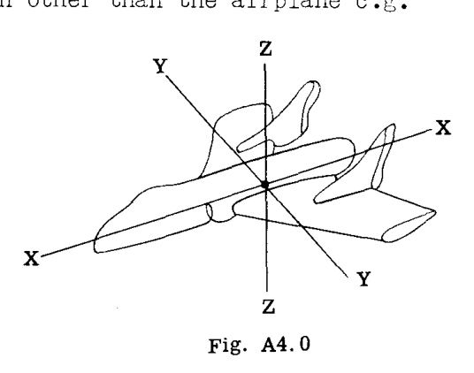

基準軸

## A4.4 自重および慣性力

重量という用語は、その質量に比例し、すべての物理的物体を地球の中心に向かって引き付けようとする一定の力である。定常飛行（等速飛行）における航空機には、航空機の重量、航空機全体に作用する空気力、およびパワーユニットによる力という、平衡状態にある力体系が作用している。操縦士は、エンジン出力を変更するか、または舵面を操作して航空機の速度方向を変更することにより、このバランスの取れた定常飛行状態を変更することができる。これらの不釣合いな力は、航空機を加速または減速させる原因となる。

### 剛体の純粋な並進運動に対する慣性力

剛体に作用する不釣合いな力が、物体の速度の大きさのみを変化させ、その方向を変化させない場合、その運動は並進運動と呼ばれ、物理学の基礎から、加速力は $F = Ma$ である。ここで、 $M$ は物体の質量、または $W/g$ である。図 A4.1 では、不釣合いな力体系 $F$ によって剛体が右方向に加速される。図 A4.2 は、この不釣合いな力が各質量粒子 $m_1a, m_2a$ などに力を生じさせる効果を示しており、したがって全有効力は $\Sigma ma = Ma$ となる。これらの有効力を反転させた場合、それらは慣性力と呼ばれる。したがって、外力と慣性力は平衡状態にある力体系を形成する。

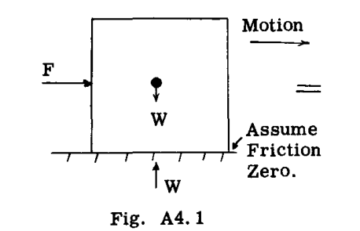

並進運動の力

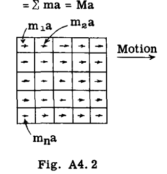

有効力

物理学の基礎から、加速度が一定である純粋な並進運動に対して、以下の関係式が得られる。

$$v - v_0 = at \quad \text{--- (1)}$$

$$s = v_0t + \frac{1}{2}at^2 \quad \text{--- (2)}$$

$$v^2 - v_0^2 = 2as \quad \text{--- (3)}$$

ここで、 - $s$ = 時間 $t$ 内に移動した距離 - $v_0$ = 初速度 - $v$ = 時間 $t$ 後の終速度

### 回転剛体に作用する慣性力

一般的な航空機の操縦（マニューバ）は、航空機の $XZ$ 面に平行な平面内の曲線経路に沿った運動であり、一般にピッチングプレーンと呼ばれる。定常飛行からの引き起こし（プルアップ）または急降下からの引き起こし（プルアウト）により、航空機は曲線経路を追従する。図 A4.3 は、曲線経路に沿って飛行する航空機を示している。点 A において、速度がその経路に沿って増加している場合、航空機は2つの加速度、すなわち、点 A において曲線に接し、大きさが以下に等しい接線加速度 $a_t$ を受ける。

$$a_t = \bar{r}\alpha$$

および、点 A において飛行経路に垂直で、回転中心 (o) に向かう加速度 $a_n$ を受ける。

$$a_n = \bar{r}\omega^2$$

ニュートンの法則から、これらの加速度による有効力は以下のようになる。

$$F_n = M\bar{r}\omega^2 = M\frac{v^2}{\bar{r}} \quad \text{--- (4)}$$

$$F_t = M\bar{r}\alpha \quad \text{--- (5)}$$

ここで、 - $\omega$ = 点 A における角速度 - $\alpha$ = 点 A における角加速度 - $\bar{r}$ = 点 A における飛行経路の曲率半径

慣性力は、図 A4.3 に示されるように、これらの有効力と大きさが等しく方向が反対である。これらの慣性力は、平衡状態にある航空機上の全力体系の一部として考えることができる。

経路に沿った航空機の速度が一定である場合、 $a_t = 0$ となり、したがって慣性力 $F_t = 0$ となり、法線慣性力 $F_n$ のみが残る。

角加速度が一定である場合、以下の関係式が成り立つ。

$$\omega - \omega_0 = \alpha t \quad \text{--- (6)}$$

$$\theta = \omega_0t + \frac{1}{2}\alpha t^2 \quad \text{--- (7)}$$

$$\omega^2 - \omega_0^2 = 2\alpha\theta \quad \text{--- (8)}$$

ここで、 - $\theta$ = 時間 $t$ 内の回転角 - $\omega_0$ = $\text{rad/sec}$ 単位の初期角速度 - $\omega$ = 時間 $t$ 後の角速度

図 A4.3 において、回転中心 (o) のまわりの慣性力のモーメント $T_o$ は $M\bar{r}\alpha(\bar{r}) = M\bar{r}^2\alpha$ に等しい。項 $M\bar{r}^2$ は、回転中心 (o) のまわりの航空機の質量慣性モーメントである。航空機はそれ自体の重心軸まわりにかなりのピッチング慣性モーメントを持っているため、これを含める必要がある。したがって、平行軸の定理により、

$$T_o = I_o\alpha + I_{c.g.}\alpha \quad \text{--- (9)}$$

ここで、 $I_o = M\bar{r}^2$ であり、 $I_{c.g.}$ = 航空機の重心を通る $Y$ 軸まわりの航空機の慣性モーメントである。

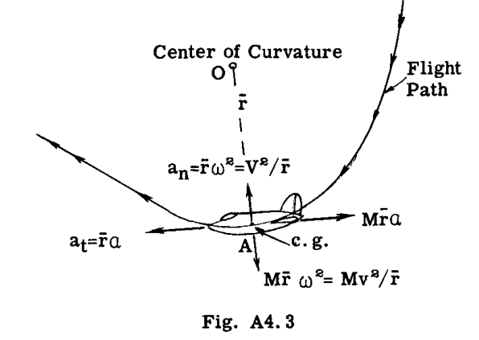

曲線経路の加速度

### 航空機の重心を通る Y 軸まわりのピッチング回転に対する慣性力

飛行中、突風が水平尾翼に衝突し、航空機の c.g. まわりにモーメントを持つ尾翼力を生じさせることがある。一部の着陸状態においては、地面または水面からの力が航空機の c.g. を通らないため、航空機の c.g. まわりにモーメントを生じさせる。これらのモーメントは、航空機を c.g. を通る $Y$ 軸まわりに回転させる。

したがって、この効果単独に対して、図 A4.3 における回転中心は (o) ではなく、航空機の c.g. にあり、 $\bar{r} = 0$ となる。したがって、 $F_n$ および $F_t$ はゼロに等しく、純粋な回転に対する唯一の慣性力は $I_{c.g.}\alpha$ （偶力）であり、したがって、航空機の c.g. まわりのこの慣性偶力のモーメントは以下のようになる。

$$T_{c.g.} = I_{c.g.}\alpha$$

前述のように、慣性力が航空機に作用する他のすべての実用荷重に含まれている場合、航空機は静的平衡状態にあり、問題は静的平衡方程式によって処理される。

## A4.5 翼に作用する空気力

航空機の主翼は、空気力の大部分を支持している。水平定常飛行において、主翼にかかる空気の垂直上向きの力は、実質的に航空機の重量に等しい。「翼型（エアフォイル）」という用語は、主翼の横断面の形状を指すときに使用される。図 A4.4 および 図 A4.5 は、正および負の迎角に対する翼型形状の周囲を流れる気流による空気圧強度分布図を示している。この図の形状と強度は、翼型自体の形状、厚さ対翼弦比、上面および下面のキャンバーなどの多くの要因によって影響を受ける。通常の主翼は胴体に取り付けられており、外部パワーユニット、翼端タンクなどを支持することがある。さらに、通常の主翼は通常、平面形状および厚さがテーパーされており、高い揚力や制御効果を生み出すために、前縁および後縁のスロットやフラップを備えていることがある。主翼周囲の流れは、上述のような要因に影響されるため、主翼上の空気力に関して、その翼弦方向およびスパン方向の分布の正確な全体像を得るには、通常、風洞試験が必要である。

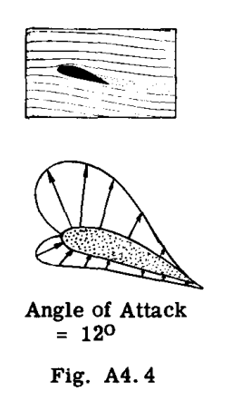

迎角12度

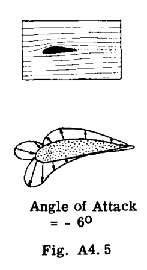

迎角マイナス6度

### 合空気力。風圧中心。

航空機全体のバランスや平衡を扱う場合、主翼上の全空気力の合力を扱うと便利である。例えば、図 A4.6 と 図 A4.7 における2つの空気圧強度分布図を考慮する。これらの分布力体系は、その合力 ( $R$ ) で置き換えることができ、これは当然、大きさ、方向、および位置が既知でなければならない。その位置は、合力 $R$ が翼型翼弦線と交差する点である風圧中心（c.p.）と呼ばれる用語で指定される。迎角が変化すると、合空気力は大きさ、方向、および風圧中心位置が変化する。

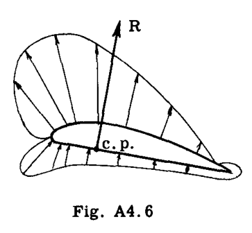

圧力分布1

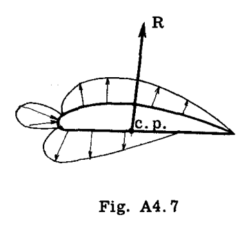

圧力分布2

### 合空気力の揚力および抗力成分

合力 $R$ を直接扱う代わりに、空気力学および応力解析の検討の双方において、合力を気流に対して垂直および平行な2つの成分に置き換えることが便利である。図 A4.8 は、この揚力（Lift）および抗力（Drag）成分への分解を示している。

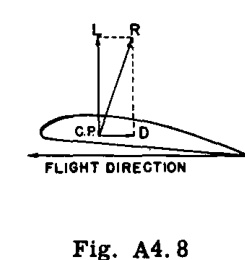

揚力と抗力

### 空力中心 (a.c.)

航空機は多くの異なる迎角で飛行するため、多くの飛行設計条件に対して風圧中心が変化することを意味する。しかし、翼型上には、迎角のいかなる値に対しても、揚力および抗力によるモーメントが一定となる点が1つ存在する。この点は空力中心（a.c.）と呼ばれ、そのおおよその位置は前縁から測定して翼弦の25%の位置にある。したがって、合力 $R$ は、図 A4.9 に示すように、空力中心における揚力および抗力と、翼モーメント $M_{a.c.}$ に置き換えることができる。

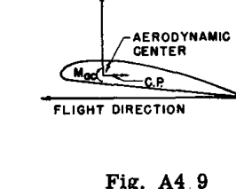

空力中心

## A4.6 飛行中の航空機に作用する力

図 A4.10 は、加速飛行状態における航空機に作用する主な力を一般的に示している。

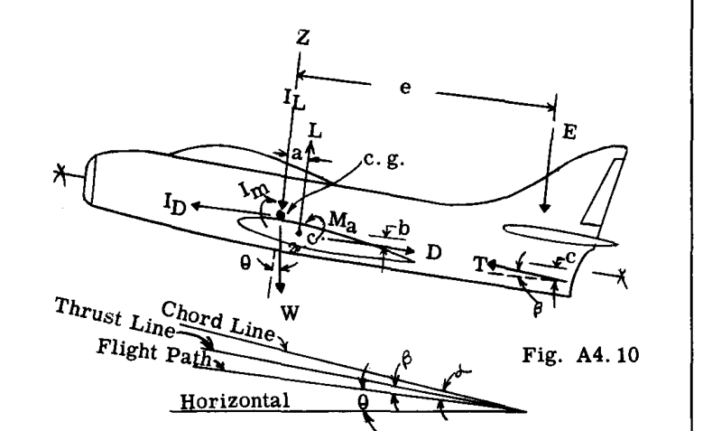

飛行中の力

- $T$ = エンジン推力
- $L$ = 主翼全揚力に胴体揚力を加えたもの
- $D$ = 航空機全抗力
- $M_{a.c.}$ = 翼空力中心（a.c.）を基準とした $L$ および $D$ のモーメント
- $W$ = 航空機重量
- $I_L$ = 飛行経路に垂直な慣性力
- $I_D$ = 飛行経路に平行な慣性力
- $I_m$ = 回転慣性モーメント
- $E$ = 飛行経路に垂直な尾翼荷重

水平等速飛行状態においては、慣性力 $I_L, I_D$ および $I_m$ はゼロになる。角加速度は伴わないがそれ自体の c.g. 軸まわりの並進運動を伴う加速飛行状態においては、慣性モーメント $I_m$ はゼロになるが、 $I_L$ および $I_D$ は値を持つ。

### 定常飛行における平衡方程式

図 A4.10 から、以下のように書くことができる。

$$\Sigma F_x = 0, \quad D + W \sin\theta - T \cos\beta = 0$$

$$\Sigma F_z = 0, \quad L - W \cos\theta + T \sin\beta - E = 0$$

$$\Sigma M_y = 0, \quad -M_{a.c.} - La - Db + Tc \cos\beta + Ee = 0$$

### 加速飛行における平衡方程式

$$\Sigma F_x = 0, \quad D + W \sin\theta - T \cos\beta - I_D = 0$$

$$\Sigma F_z = 0, \quad L - W \cos\theta + T \sin\beta - I_L - E = 0$$

$$\Sigma M_y = 0, \quad -M_{a.c.} - La - Db + Tc \cos\beta + Ee + I_m = 0$$

使用された符号： - 力：プラスは上向きおよび尾部方向。 - モーメント：時計回りがプラス。 - c.g. から力までの距離：プラスは上向きおよび尾部方向。

## A4.7 荷重倍数

通常、記号 ( $n$ ) で表される「荷重倍数（Load Factor）」という用語は、定常飛行における航空機に作用する力を乗じて、航空機の加速中に作用する動的力体系に等価な静的力体系を得るための数値倍率として定義できる。図 A4.11 は、定常水平飛行における力を示している。

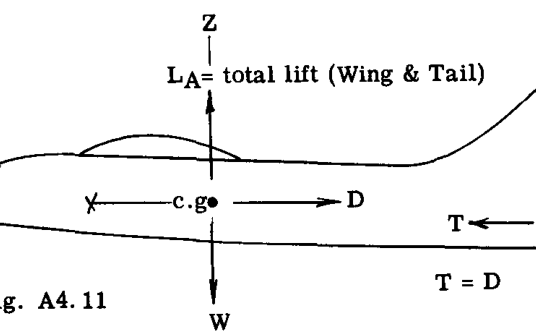

定常飛行

$L$ は航空機の全揚力（主翼プラス尾翼）を表す。したがって、 $L = W$ である。ここで、航空機が $Z$ 軸に沿って上向きに加速されていると仮定する。図 A4.12 は、下向き、すなわち加速度の方向と反対に作用する追加の慣性力 $W a_z / g$ を示している。

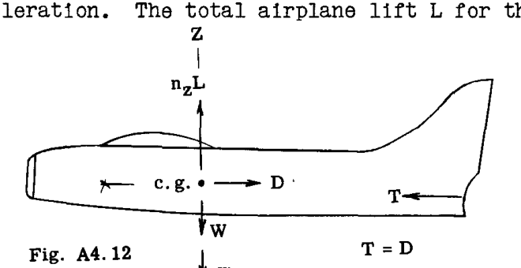

加速飛行 Z軸

図 A4.11 における非加速状態に対する航空機の全揚力 $L$ は、制限荷重倍数 $n_z$ を乗じて、 $z$ 方向の静的平衡状態を作り出さなければならない。

したがって、

$$n_z L - W - \frac{W}{g} a_z = 0$$

$L = W$ であるため、

$$n_z = 1 + \frac{a_z}{g}$$

航空機は当然、 $Z$ 軸だけでなく $X$ 軸に沿っても加速される。したがって、図 A4.13 において、エンジン推力 $T$ の大きさは航空機の抗力 $D$ よりも大きく、これにより航空機は前方に加速される。 $X$ 方向の慣性力を荷重倍数 $n_x$ で表すと便利である。

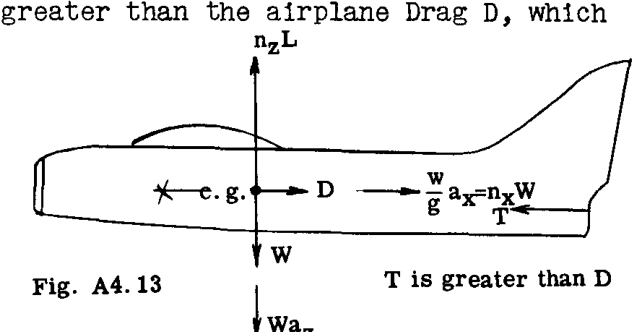

加速飛行 X軸

航空機の重量 $W$ 、したがって、

$$n_x W = \frac{W}{g} a_x \quad (\text{図 A4.13 参照})$$

$$\Sigma F_x = 0, \quad \text{すなわち } T - D - n_x W = 0$$

したがって、

$$n_x = \frac{T - D}{W}$$

したがって、航空機に作用する荷重は荷重倍数の観点から議論することができる。実用または制限荷重倍数は、特定の航空機の運航中に発生する可能性のある最大荷重倍数である。A4.2 節で議論したように、これらの荷重は、目立った永久変形を伴うことなく航空機構造によって支持されなければならない。設計荷重倍数は、制限荷重倍数に安全率を乗じたものに等しく、これらの設計荷重は、破断や崩壊、換言すれば完全な破壊を伴うことなく構造によって支持されなければならない。

## A4.8 航空機の設計飛行要件

民間および軍事の航空当局は、様々な分類の航空機に対する設計条件を規定する要件を発行している。一般的に言えば、いかなる航空機の飛行状態も、荷重倍数（加速度）と飛行速度（より正確には動圧）の既存の値を指定することによって定義できる。

航空機に生じる加速度は、操縦（マニューバ）と突風という2つの原因から発生する。操縦による加速度は、特定の加速度を超えないように操縦装置を操作することができる操縦士の制御下にある。機動性の高い軍用機では、加速度倍数を制限するためのガイドとして、コックピットの計器に加速度計が含まれている。民間航空機の場合、操縦倍数は、特定のタイプの航空機の必要な飛行運用において必要とされるあらゆる操縦を安全に行うのに十分に高く設定されている。これらの制限操縦倍数は、長年の運用経験に基づいており、重量設計の観点から航空機に不利益を与えることなく、安全上の観点から満足のいく結果を与えている。

航空機が突風に遭遇することによる加速度は、突風の方向と速度に依存するため、操縦士の制御下にはない。民間および軍用航空機に加速度計を設置し、あらゆる気象条件および地域で飛行させることによって得られた多くの蓄積データから、毎秒 30 フィートの突風速度で十分であることが判明している。

航空機の速度も同様に航空機に作用する荷重に影響を与える。速度が高くなればなるほど、空気力学的翼モーメントは高くなる。さらに、突風加速度は航空機の速度とともに増加する。したがって、特定の航空機を明確な最大飛行速度に制限することが慣例となっている。民間航空機の場合、速度は、合理的な飛行運用に対応するのに十分な合理的な滑空速度に制限されている。

## A4.9 突風荷重倍数

鋭い突風が、推力線（ $X$ 軸）に垂直な方向から航空機に衝突すると、航空機の速度に急激な変化を伴うことなく、主翼の迎角に急激な変化が生じる。垂直力係数（ $C_{z_A}$ ）は、迎角に対して線形に変化すると仮定できる。したがって、図 (a) において、点 (B) が速度 $V$ で水平飛行を維持するのに必要な通常の航空機力係数 $C_{z_A}$ を表し、点 (C) が、鋭い突風 $KU$ が速度 $V$ の変化を伴わずに迎角に急激な変化 $\Deltȃ\alpha$ を引き起こした後の $C_{z_A}$ の値を表すとする。したがって、 $Z$ 方向における航空機荷重の全増加量は、点 B における比率 $C_{z_A}$ によって表すことができる。

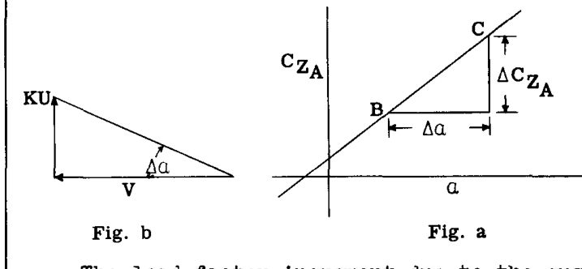

突風特性

図 (b) から、小さな角度に対して $\Delta\alpha = KU/V$ であり、図 (a) から $\Delta C_{z_A} = m \Delta\alpha$ である。ここで、 $m$ = 航空機の垂直力曲線の傾き（ラジアンあたり $C_{z_A}$ ）である。

突風 $KU$ による荷重倍数の増分は、以下のように表すことができる。

$$\Delta n = \frac{\Delta C_{z_A}}{C_{z_A}} = \frac{\left(\frac{KUm}{V}\right) \left(\rho V^2 S\right)}{\frac{2W}{575}} = \frac{KU V S m}{575 W} \quad \text{--- (A)}$$

ここで、 - $U$ = $\text{ft./sec.}$ 単位の突風速度 - $K^*$ = 翼荷重に依存する突風補正係数（ $K$ の曲線は民間航空局によって提供されている）。 - $V$ = マイル毎時単位の指示対気速度。 - $S$ = 平方フィート単位の主翼面積。 - $W$ = 航空機の総重量。

- NACA Technical Note 2964（1953年6月）では、緩和係数 $K$ を突風係数 $K_g = 0.88 M_g / (5.3 + M_g)$ に置き換えることを提案している。この式において、 $M_g$ は航空機の質量比または質量パラメータ $2 W / (a \rho c g s)$ であり、ここで $c$ はフィート単位の平均幾何翼弦、 $g$ は重力加速度である。

$U$ を毎秒 30 フィートとし、 $m$ を絶対単位から度あたりの角度に対する $C_{z_A}$ の変化とすると、式 (A) は以下のように簡約される。

$$\Delta n = \frac{3KmV}{W/S} \quad \text{--- (B)}$$

したがって、航空機が水平姿勢で飛行しているときの突風荷重倍数 $n$ は、以下に等しくなる。

$$n = 1 + \frac{3KmV}{W/S} \quad \text{--- (C)}$$

また、航空機が垂直姿勢にあるときは、以下のようになる。

$$n = \pm \frac{3KmV}{W/S} \quad \text{--- (D)}$$

## A4.10 主な飛行条件の例示。速度-荷重倍数図。

前述のように、航空機の主な設計飛行条件は、加速度と速度の制限値、および実用突風速度の最大値を指定することによって与えることができる。例として、特定の航空機に対する設計荷重要件は、以下のように述べることができる。

「提案された航空機は、 $C_{L_{\max}}$ に対応する速度から最大水平飛行速度の 1.4 倍までのすべての速度において、それぞれ $+6.0g$ および $-3.5g$ の実用正および負の加速度に対して設計されるものとする。さらに、航空機は、最大水平飛行速度の 1.4 倍の制限速度に達するまで、任意の方向に作用する毎秒 30 フィートの突風によるいかなる実用荷重にも耐えるものとする。これらの実用荷重には 1.5 の設計安全率を使用するものとする。」

必要とされる操縦倍数が比較的低い航空機の場合、突風加速度は正および負の双方の加速度に対して臨界になることがある。突風方程式の検討は、最も軽い荷重状態（最小総重量）が最大の突風荷重倍数を生み出し、したがって部分的なペイロードや燃料のみが関与することを示している。

基本的に、民間航空局、陸軍、および海軍の飛行条件要件は、規定された速度と加速度の考慮、および突風の考慮に基づいている。したがって、上記の基本的な議論を理解している学生は、これら3つの政府機関の設計要件を理解する上で困難はないはずである。

応力解析の目的上、すべての速度は指示対気速度として表される。「指示」対気速度は、完全な対気速度計、すなわち、標準大気状態における海面上での真対気速度を示す計器によって指示される速度として定義される。実際の対気速度 $V_a$ と指示対気速度 $V_i$ の関係は、以下の式によって与えられる。

$$V_i = \sqrt{\frac{\rho_a}{\rho_0}} V_a$$

ここで、 - $V_i$ = 指示対気速度 - $V_a$ = 実際の対気速度 - $\rho_0$ = 海面上における標準空気密度 - $\rho_a$ = $V_a$ が達成される空気の密度